# 收集

## / import lib

```python
# import libs

## official libs
import pprint as pp

## 3rd libs
import pandas as pd
import numpy as np

import matplotlib.pyplot as plt
from PIL import Image

## private libs
import wrangling1 as w

## paras
%matplotlib inline
```

```python
# import libs
## official libs
import pprint  as pp

## third libs
import pandas as pd
import numpy as np

## private libs
import wrangling1 as w
# 包括了一些数据评估的简单功能
```

## / load df

```python
# load df
## read_jason 有很多参数,可以参考官方文档
## 此处要加 lines=True
df = pd.read_json('tweet_json.txt',lines=True)
# https://pandas.pydata.org/pandas-docs/stable/reference/api/pandas.read_json.html
```

```python
# load df
## read_jason 有很多参数,可以参考官方文档
## 此处要加 lines=True
df = pd.read_json('tweet_json.txt',lines=True)
# https://pandas.pydata.org/pandas-docs/stable/reference/api/pandas.read_json.html
```

## / check df

```python
w.check_sample(df)
```

```
----checking sample index: 187

- columns #1 : contributors
[nan]

- columns #2 : coordinates
[nan]

- columns #3 : created_at
['2017-04-22T18:55:51.000000000']

- columns #4 : display_text_range
[list([0, 89])]

- columns #5 : entities
[{'hashtags': [], 'symbols': [], 'user_mentions': [], 'urls': [{'url': 'https://t.co/sb73bV5Y7S', 'expanded_url': 'https://twitter.com/perfy/status/855857318168150016', 'display_url': 'twitter.com/perfy/status/8…', 'indices': [90, 113]}]}]

- columns #6 : extended_entities
[nan]

- columns #7 : favorite_count
[12449]

- columns #8 : favorited
[False]

- columns #9 : full_text
['HE\'S LIKE "WAIT A MINUTE I\'M AN ANIMAL THIS IS AMAZING HI HUMAN I LOVE YOU AS WELL" 13/10 https://t.co/sb73bV5Y7S']

- columns #10 : geo-----
[nan]

- columns #11 : id------
[855857698524602368]

- columns #12 : id_str--
[855857698524602368]

- columns #13 : in_reply_to_screen_name
[None]
```

[output cut: 40 more lines]

```
- columns #27 : retweeted
[False]

- columns #28 : retweeted_status
[nan]

- columns #29 : source--
['<a href="http://twitter.com/download/iphone" rel="nofollow">Twitter for iPhone</a>']

- columns #30 : truncated
[False]

- columns #31 : user----
[{'id': 4196983835, 'id_str': '4196983835', 'name': 'SpookyWeRateDogs™', 'screen_name': 'dog_rates', 'location': 'MERCH↴  DM DOGS. WE WILL RATE', 'description': 'Only Legit Source for Professional Dog Ratings STORE: @ShopWeRateDogs | IG, FB & SC: WeRateDogs | MOBILE APP: @GoodDogsGame Business: dogr…
'----checking complete----'
```

```python
df.columns
```

```
Index(['contributors', 'coordinates', 'created_at', 'display_text_range',
       'entities', 'extended_entities', 'favorite_count', 'favorited',
       'full_text', 'geo', 'id', 'id_str', 'in_reply_to_screen_name',
       'in_reply_to_status_id', 'in_reply_to_status_id_str',
       'in_reply_to_user_id', 'in_reply_to_user_id_str', 'is_quote_status',
       'lang', 'place', 'possibly_sensitive', 'possibly_sensitive_appealable',
       'quoted_status', 'quoted_status_id', 'quoted_status_id_str',
       'retweet_count', 'retweeted', 'retweeted_status', 'source', 'truncated',
       'user'],
      dtype='object')
```

```python
df.info()
```

```
<class 'pandas.core.frame.DataFrame'>
RangeIndex: 2352 entries, 0 to 2351
Data columns (total 31 columns):
contributors                     0 non-null float64
coordinates                      0 non-null float64
created_at                       2352 non-null datetime64[ns]
display_text_range               2352 non-null object
entities                         2352 non-null object
extended_entities                2073 non-null object
favorite_count                   2352 non-null int64
favorited                        2352 non-null bool
full_text                        2352 non-null object
geo                              0 non-null float64
id                               2352 non-null int64
id_str                           2352 non-null int64
in_reply_to_screen_name          78 non-null object
in_reply_to_status_id            78 non-null float64
in_reply_to_status_id_str        78 non-null float64
in_reply_to_user_id              78 non-null float64
in_reply_to_user_id_str          78 non-null float64
is_quote_status                  2352 non-null bool
lang                             2352 non-null object
place                            1 non-null object
possibly_sensitive               2211 non-null float64
possibly_sensitive_appealable    2211 non-null float64
quoted_status                    28 non-null object
quoted_status_id                 29 non-null float64
quoted_status_id_str             29 non-null float64
retweet_count                    2352 non-null int64
retweeted                        2352 non-null bool
retweeted_status                 177 non-null object
source                           2352 non-null object
truncated                        2352 non-null bool
user                             2352 non-null object
dtypes: bool(4), datetime64[ns](1), float64(11), int64(4), object(11)
memory usage: 505.4+ KB
```

```python
df.describe()
```

|  | contributors | coordinates | favorite_count | geo | id | id_str | in_reply_to_status_id | in_reply_to_status_id_str | in_reply_to_user_id | in_reply_to_user_id_str | possibly_sensitive | possibly_sensitive_appealable | quoted_status_id | quoted_status_id_str | retweet_count |
| --- | --- | --- | --- | --- | --- | --- | --- | --- | --- | --- | --- | --- | --- | --- | --- |
| count | 0.0 | 0.0 | 2352.000000 | 0.0 | 2.352000e+03 | 2.352000e+03 | 7.800000e+01 | 7.800000e+01 | 7.800000e+01 | 7.800000e+01 | 2211.0 | 2211.0 | 2.900000e+01 | 2.900000e+01 | 2352.000000 |
| mean | NaN | NaN | 8109.198980 | NaN | 7.425913e+17 | 7.425913e+17 | 7.455079e+17 | 7.455079e+17 | 2.014171e+16 | 2.014171e+16 | 0.0 | 0.0 | 8.162686e+17 | 8.162686e+17 | 3134.932398 |
| std | NaN | NaN | 11980.795669 | NaN | 6.846210e+16 | 6.846210e+16 | 7.582492e+16 | 7.582492e+16 | 1.252797e+17 | 1.252797e+17 | 0.0 | 0.0 | 6.164161e+16 | 6.164161e+16 | 5237.846296 |
| min | NaN | NaN | 0.000000 | NaN | 6.660209e+17 | 6.660209e+17 | 6.658147e+17 | 6.658147e+17 | 1.185634e+07 | 1.185634e+07 | 0.0 | 0.0 | 6.721083e+17 | 6.721083e+17 | 0.000000 |
| 25% | NaN | NaN | 1417.000000 | NaN | 6.783949e+17 | 6.783949e+17 | 6.757419e+17 | 6.757419e+17 | 3.086374e+08 | 3.086374e+08 | 0.0 | 0.0 | 7.888183e+17 | 7.888183e+17 | 618.000000 |
| 50% | NaN | NaN | 3596.500000 | NaN | 7.193536e+17 | 7.193536e+17 | 7.038708e+17 | 7.038708e+17 | 4.196984e+09 | 4.196984e+09 | 0.0 | 0.0 | 8.340867e+17 | 8.340867e+17 | 1456.500000 |
| 75% | NaN | NaN | 10118.000000 | NaN | 7.991219e+17 | 7.991219e+17 | 8.257804e+17 | 8.257804e+17 | 4.196984e+09 | 4.196984e+09 | 0.0 | 0.0 | 8.664587e+17 | 8.664587e+17 | 3628.750000 |
| max | NaN | NaN | 132318.000000 | NaN | 8.924206e+17 | 8.924206e+17 | 8.862664e+17 | 8.862664e+17 | 8.405479e+17 | 8.405479e+17 | 0.0 | 0.0 | 8.860534e+17 | 8.860534e+17 | 79116.000000 |

# 评估

## / quanlity

### // drop1

```python
# drop list1
## 先删除重复和无意义的信息
droplist1 = ['contributors','coordinates','geo','place','id_str',
             'in_reply_to_status_id_str','in_reply_to_user_id_str','quoted_status_id_str']
```

```python
## drop list1 excute
w.drop_column(df,droplist1)
```

```
---- proceding ----
- drop 8 columns: ['contributors', 'coordinates', 'geo', 'place', 'id_str', 'in_reply_to_status_id_str', 'in_reply_to_user_id_str', 'quoted_status_id_str']
- remain 23 columns
- success : True
```

### // check - inspect list

对一些怀疑是否有用的数据进行检视

```python
# check1
## snip remained columns
w.check_sample(df)
```

```
----checking sample index: 1735

- columns #1 : created_at
['2015-12-23T03:58:25.000000000']

- columns #2 : display_text_range
[list([0, 133])]

- columns #3 : entities
[{'hashtags': [], 'symbols': [], 'user_mentions': [], 'urls': [], 'media': [{'id': 679511347441328128, 'id_str': '679511347441328128', 'indices': [110, 133], 'media_url': 'http://pbs.twimg.com/media/CW4b-GUWYAAa8QO.jpg', 'media_url_https': 'https://pbs.twimg.com/media/CW4b-GUWYAAa8QO.jpg', 'url': 'h…

- columns #4 : extended_entities
[{'media': [{'id': 679511347441328128, 'id_str': '679511347441328128', 'indices': [110, 133], 'media_url': 'http://pbs.twimg.com/media/CW4b-GUWYAAa8QO.jpg', 'media_url_https': 'https://pbs.twimg.com/media/CW4b-GUWYAAa8QO.jpg', 'url': 'https://t.co/bwuV6FlRxr', 'display_url': 'pic.twitter.com/bwuV6Fl…

- columns #5 : favorite_count
[3694]

- columns #6 : favorited
[False]

- columns #7 : full_text
["Say hello to William. He makes fun of others because he's terrified of his own deep-seated insecurities. 7/10 https://t.co/bwuV6FlRxr"]

- columns #8 : id------
[679511351870550016]

- columns #9 : in_reply_to_screen_name
[None]

- columns #10 : in_reply_to_status_id
[nan]

- columns #11 : in_reply_to_user_id
[nan]

- columns #12 : is_quote_status
[False]

- columns #13 : lang----
['en']
```

[output cut: 16 more lines]

```
- columns #19 : retweeted
[False]

- columns #20 : retweeted_status
[nan]

- columns #21 : source--
['<a href="http://twitter.com/download/iphone" rel="nofollow">Twitter for iPhone</a>']

- columns #22 : truncated
[False]

- columns #23 : user----
[{'id': 4196983835, 'id_str': '4196983835', 'name': 'SpookyWeRateDogs™', 'screen_name': 'dog_rates', 'location': 'MERCH↴  DM DOGS. WE WILL RATE', 'description': 'Only Legit Source for Professional Dog Ratings STORE: @ShopWeRateDogs | IG, FB & SC: WeRateDogs | MOBILE APP: @GoodDogsGame Business: dogr…
'----checking complete----'
```

```python
## define inspect list1
inslist1 = ['favorited','in_reply_to_screen_name','in_reply_to_status_id',
            'in_reply_to_user_id','is_quote_status','lang','possibly_sensitive',
            'possibly_sensitive_appealable','quoted_status_id','retweeted','truncated']
```

```python
## inspect info
df[inslist1].info()
```

```
<class 'pandas.core.frame.DataFrame'>
RangeIndex: 2352 entries, 0 to 2351
Data columns (total 11 columns):
favorited                        2352 non-null bool
in_reply_to_screen_name          78 non-null object
in_reply_to_status_id            78 non-null float64
in_reply_to_user_id              78 non-null float64
is_quote_status                  2352 non-null bool
lang                             2352 non-null object
possibly_sensitive               2211 non-null float64
possibly_sensitive_appealable    2211 non-null float64
quoted_status_id                 29 non-null float64
retweeted                        2352 non-null bool
truncated                        2352 non-null bool
dtypes: bool(4), float64(5), object(2)
memory usage: 137.9+ KB
```

```python
## inspect value
w.check_value(df,inslist1)
```

```
- columns #1 : favorited
False    2352
Name: favorited, dtype: int64

- columns #2 : in_reply_to_screen_name
dog_rates       47
markhoppus       2
jonnysun         1
xianmcguire      1
ComplicitOwl     1
Name: in_reply_to_screen_name, dtype: int64

- columns #3 : in_reply_to_status_id
6.671522e+17    2
8.562860e+17    1
8.131273e+17    1
6.754971e+17    1
6.827884e+17    1
Name: in_reply_to_status_id, dtype: int64

- columns #4 : in_reply_to_user_id
4.196984e+09    47
2.195506e+07     2
7.305050e+17     1
2.916630e+07     1
3.105441e+09     1
Name: in_reply_to_user_id, dtype: int64

- columns #5 : is_quote_status
False    2321
True       31
Name: is_quote_status, dtype: int64

- columns #6 : lang----
en     2334
und       7
in        3
nl        3
ro        1
Name: lang, dtype: int64
```

[output cut: 10 more lines]

```
8.340867e+17    1
8.413114e+17    1
7.061659e+17    1
8.860534e+17    1
8.464848e+17    1
Name: quoted_status_id, dtype: int64

- columns #10 : retweeted
False    2352
Name: retweeted, dtype: int64

- columns #11 : truncated
False    2352
Name: truncated, dtype: int64
'----checking complete----'
```

### // check - quoted_status

```python
# special1 quoted_status
## quoted_status is a dict, move it to detlist
## check values (almost is null)
df.quoted_status.isnull().value_counts()
```

```
True     2324
False      28
Name: quoted_status, dtype: int64
```

```python
## check a sample
df[df.quoted_status.notnull()].sample(1).quoted_status.iloc[0]
### this is some extra info abou a forward
```

```
{'created_at': 'Wed Apr 27 01:34:44 +0000 2016',
 'id': 725136065078521856,
 'id_str': '725136065078521856',
 'full_text': 'Se nos metió otro jugador al partido de @dvotachira vs @pumasmx en la #LibertadoresEnFD 🐶\nhttps://t.co/nPtdOeTxcW',
 'truncated': False,
 'display_text_range': [0, 113],
 'entities': {'hashtags': [{'text': 'LibertadoresEnFD', 'indices': [70, 87]}],
  'symbols': [],
  'user_mentions': [{'screen_name': 'DvoTachira',
    'name': 'Deportivo Táchira FC',
    'id': 85361349,
    'id_str': '85361349',
    'indices': [40, 51]},
   {'screen_name': 'PumasMX',
    'name': 'PUMAS',
    'id': 78938710,
    'id_str': '78938710',
    'indices': [55, 63]}],
  'urls': [{'url': 'https://t.co/nPtdOeTxcW',
    'expanded_url': 'https://amp.twimg.com/v/47e2d017-ad5d-4716-a8ce-5173b32e0a18',
    'display_url': 'amp.twimg.com/v/47e2d017-ad5…',
    'indices': [90, 113]}]},
 'source': '<a href="http://twitter.com" rel="nofollow">Twitter Web Client</a>',
 'in_reply_to_status_id': None,
 'in_reply_to_status_id_str': None,
 'in_reply_to_user_id': None,
 'in_reply_to_user_id_str': None,
 'in_reply_to_screen_name': None,
 'user': {'id': 195947234,
  'id_str': '195947234',
  'name': 'FOX Deportes',
  'screen_name': 'FOXDeportes',
  'location': '',
  'description': 'Somos la primera cadena de deportes en español en USA. Síguenos para obtener las mejores noticias del mundo deportivo y recibe alertas de nuestra programación.',
  'url': 'http://t.co/4JtKgkdxJ0',
  'entities': {'url': {'urls': [{'url': 'http://t.co/4JtKgkdxJ0',
      'expanded_url': 'http://foxdeportes.com',
      'display_url': 'foxdeportes.com',
      'indices': [0, 22]}]},
   'description': {'urls': []}},
```

[output cut: 31 more lines]

```
  'follow_request_sent': False,
  'notifications': False,
  'translator_type': 'none'},
 'geo': None,
 'coordinates': None,
 'place': None,
 'contributors': None,
 'is_quote_status': False,
 'retweet_count': 4450,
 'favorite_count': 5040,
 'favorited': False,
 'retweeted': False,
 'possibly_sensitive': False,
 'possibly_sensitive_appealable': False,
 'lang': 'es'}
```

- 分析 `quoted_status`:
  - 是嵌套字典数据
  - 缺失很多(只有28个数据)
  - 内容无用信息比较多
- 结论:
  - 删除此列
  - user 列和此列类似,也删除

### // check - in_reply_to_screen_name

```python
# special2
## in_reply_to_screen_name have value dog_rates for 47 times
df.query('in_reply_to_screen_name == "dog_rates"')[:3]
```

|  | created_at | display_text_range | entities | extended_entities | favorite_count | favorited | full_text | id | in_reply_to_screen_name | in_reply_to_status_id | ... | possibly_sensitive | possibly_sensitive_appealable | quoted_status | quoted_status_id | retweet_count | retweeted | retweeted_status | source | truncated | user |
| --- | --- | --- | --- | --- | --- | --- | --- | --- | --- | --- | --- | --- | --- | --- | --- | --- | --- | --- | --- | --- | --- |
| 147 | 2017-05-12 17:12:53 | [0, 139] | {'hashtags': [], 'symbols': [], 'user_mentions... | {'media': [{'id': 863079538779013120, 'id_str'... | 9068 | False | Ladies and gentlemen... I found Pipsy. He may ... | 863079547188785154 | dog_rates | 6.671522e+17 | ... | 0.0 | 0.0 | NaN | NaN | 1188 | False | NaN | <a href="http://twitter.com/download/iphone" r... | False | {'id': 4196983835, 'id_str': '4196983835', 'na... |
| 181 | 2017-04-24 15:13:52 | [0, 112] | {'hashtags': [], 'symbols': [], 'user_mentions... | {'media': [{'id': 856526604033556482, 'id_str'... | 12412 | False | THIS IS CHARLIE, MARK. HE DID JUST WANT TO SAY... | 856526610513747968 | dog_rates | 8.558181e+17 | ... | 0.0 | 0.0 | NaN | NaN | 2053 | False | NaN | <a href="http://twitter.com/download/iphone" r... | False | {'id': 4196983835, 'id_str': '4196983835', 'na... |
| 225 | 2017-04-01 16:41:12 | [0, 135] | {'hashtags': [], 'symbols': [], 'user_mentions... | NaN | 8799 | False | Jerry just apuppologized to me. He said there ... | 848213670039564288 | dog_rates | 8.482121e+17 | ... | NaN | NaN | NaN | NaN | 825 | False | NaN | <a href="http://twitter.com/download/iphone" r... | False | {'id': 4196983835, 'id_str': '4196983835', 'na... |

3 rows × 23 columns

```python
df['in_reply_to_screen_name'].isnull().sum() / df.shape[0]
```

```
0.9668367346938775
```

- 分析`in_reply_to_screen_name`:
  - 可能 `dog_rates` 是默认回复名字
  - 数据缺失率为 97%
- 结论:
  - 删除数据

### // drop2

根据上面 check 内容删除数据

```python
# droplist2
droplist2 = inslist1.copy()
### use .copy to copy rather than llink
droplist2.append('quoted_status')
droplist2.append('retweeted_status')
droplist2.append('user')
#droplist2 = ['truncated','retweeted','possibly_sensitive_appealable','possibly_sensitive','lang','is_quote_status','favorited']
```

```python
## drop2 excute
w.drop_column(df,droplist2)
```

```
---- proceding ----
- drop 14 columns: ['favorited', 'in_reply_to_screen_name', 'in_reply_to_status_id', 'in_reply_to_user_id', 'is_quote_status', 'lang', 'possibly_sensitive', 'possibly_sensitive_appealable', 'quoted_status_id', 'retweeted', 'truncated', 'quoted_status', 'retweeted_status', 'user']
- remain 9 columns
- success : True
```

### // check - detail columns

对嵌套的数据进行检视

```python
# check3
## recheck sample
w.check_sample(df)
```

```
----checking sample index: 316

- columns #1 : created_at
['2017-02-22T18:59:48.000000000']

- columns #2 : display_text_range
[list([0, 139])]

- columns #3 : entities
[{'hashtags': [], 'symbols': [], 'user_mentions': [{'screen_name': 'dog_rates', 'name': 'SpookyWeRateDogs™', 'id': 4196983835, 'id_str': '4196983835', 'indices': [3, 13]}], 'urls': []}]

- columns #4 : extended_entities
[nan]

- columns #5 : favorite_count
[0]

- columns #6 : full_text
["RT @dog_rates: This is Leo. He was a skater pup. She said see ya later pup. He wasn't good enough for her. 12/10 you're good enough for me…"]

- columns #7 : id------
[834477809192075265]

- columns #8 : retweet_count
[12146]

- columns #9 : source--
['<a href="http://twitter.com/download/iphone" rel="nofollow">Twitter for iPhone</a>']
'----checking complete----'
```

```python
# detail list1
## check dict long columns
detlist1 = ['entities','extended_entities']
```

```python
# detail check
w.check_detail(df,detlist1)
### not new info  -> drop
```

```
- columns #1 : entities
{'hashtags': [],
 'media': [{'display_url': 'pic.twitter.com/MgUWQ76dJU',
            'expanded_url': 'https://twitter.com/dog_rates/status/892420643555336193/photo/1',
            'id': 892420639486877696,
            'id_str': '892420639486877696',
            'indices': [86, 109],
            'media_url': 'http://pbs.twimg.com/media/DGKD1-bXoAAIAUK.jpg',
            'media_url_https': 'https://pbs.twimg.com/media/DGKD1-bXoAAIAUK.jpg',
            'sizes': {'large': {'h': 528, 'resize': 'fit', 'w': 540},
                      'medium': {'h': 528, 'resize': 'fit', 'w': 540},
                      'small': {'h': 528, 'resize': 'fit', 'w': 540},
                      'thumb': {'h': 150, 'resize': 'crop', 'w': 150}},
            'type': 'photo',
            'url': 'https://t.co/MgUWQ76dJU'}],
 'symbols': [],
 'urls': [],
 'user_mentions': []}

- columns #2 : extended_entities
{'media': [{'display_url': 'pic.twitter.com/MgUWQ76dJU',
            'expanded_url': 'https://twitter.com/dog_rates/status/892420643555336193/photo/1',
            'id': 892420639486877696,
            'id_str': '892420639486877696',
            'indices': [86, 109],
            'media_url': 'http://pbs.twimg.com/media/DGKD1-bXoAAIAUK.jpg',
            'media_url_https': 'https://pbs.twimg.com/media/DGKD1-bXoAAIAUK.jpg',
            'sizes': {'large': {'h': 528, 'resize': 'fit', 'w': 540},
                      'medium': {'h': 528, 'resize': 'fit', 'w': 540},
                      'small': {'h': 528, 'resize': 'fit', 'w': 540},
                      'thumb': {'h': 150, 'resize': 'crop', 'w': 150}},
            'type': 'photo',
            'url': 'https://t.co/MgUWQ76dJU'}]}
```

- 分析:
  - 是嵌套字典数据
  - 缺失不多
  - 内容无用信息比较多(有些与其他列有重复)
- 结论:
  - 删除列

### // drop3

```python
# drop list3
droplist3 = detlist1.copy()

## drop3 excute
w.drop_column(df,droplist3)
```

```
---- proceding ----
- drop 2 columns: ['entities', 'extended_entities']
- remain 7 columns
- success : True
```

### // check - display_text_range

使用函数check_value会在这一列报错,检查下是因为这列的列表嵌套数字的原因

```python
# check specified
df.display_text_range.sample(5)
```

```
281     [0, 112]
2236    [0, 139]
68      [0, 132]
1516    [0, 108]
717     [0, 107]
Name: display_text_range, dtype: object
```

```python
dflist = ['created_at',
 'favorite_count',
 'full_text',
 'id',
 'retweet_count',
 'source']
```

```python
w.check_value(df,dflist)
```

```
- columns #1 : created_at
2016-09-12 15:10:21    1
2016-06-03 01:07:16    1
2017-01-31 01:27:39    1
2016-10-13 23:23:56    1
2016-06-27 01:37:04    1
Name: created_at, dtype: int64

- columns #2 : favorite_count
0       177
1753      3
3548      3
689       3
1526      3
Name: favorite_count, dtype: int64

- columns #3 : full_text
Three generations of pupper. 11/10 for all https://t.co/tAmQYvzrau                                                                             1
This is a rare Arctic Wubberfloof. Unamused by the happenings. No longer has the appetites. 12/10 would totally hug https://t.co/krvbacIX0N    1
RT @rachaeleasler: these @dog_rates hats are 13/10 bean approved https://t.co/nRCdq4g9gG                                                       1
Here we see 33 dogs posing for a picture. All get 11/10 for superb cooperation https://t.co/TRAri5iHzd                                         1
This is Beemo. He's a Chubberflop mix. 12/10 would cross the world for https://t.co/kzMVMU8HBV                                                 1
Name: full_text, dtype: int64

- columns #4 : id------
749075273010798592    1
741099773336379392    1
798644042770751489    1
825120256414846976    1
769212283578875904    1
Name: id, dtype: int64

- columns #5 : retweet_count
1280    5
312     5
745     5
1554    4
1103    4
Name: retweet_count, dtype: int64

- columns #6 : source--
<a href="http://twitter.com/download/iphone" rel="nofollow">Twitter for iPhone</a>     2217
<a href="http://vine.co" rel="nofollow">Vine - Make a Scene</a>                          91
<a href="http://twitter.com" rel="nofollow">Twitter Web Client</a>                       33
<a href="https://about.twitter.com/products/tweetdeck" rel="nofollow">TweetDeck</a>      11
Name: source, dtype: int64
'----checking complete----'
```

### // check - null data

```python
df.info()
```

```
<class 'pandas.core.frame.DataFrame'>
RangeIndex: 2352 entries, 0 to 2351
Data columns (total 7 columns):
created_at            2352 non-null datetime64[ns]
display_text_range    2352 non-null object
favorite_count        2352 non-null int64
full_text             2352 non-null object
id                    2352 non-null int64
retweet_count         2352 non-null int64
source                2352 non-null object
dtypes: datetime64[ns](1), int64(3), object(3)
memory usage: 128.7+ KB
```

```python
df.isnull().sum()
```

```
created_at            0
display_text_range    0
favorite_count        0
full_text             0
id                    0
retweet_count         0
source                0
dtype: int64
```

### // drop4

想来想去还是把 id 给drop了, 后续分析中用不到还有隐私隐患

```python
droplist4 = ['id']
w.drop_column(df,droplist4)
```

```
---- proceding ----
- drop 1 columns: ['id']
- remain 6 columns
- success : True
```

### // review (quanlity)

- id 为标识列
- created_at 包括时间、日期,可以进行时序分析
- display_text_range 为文字长度
- favorite_count 为点赞数
- full_text 为文字内容
- retweet_count 为回复数
- source 为来源

### // persistence

```python
df.to_pickle('tweet.pickle.xz', compression='xz')
```

## / tidyness

根据质量部分的输出,对于除id列之外的需要进行清洁度的整理

- created_at 包括时间、日期,可以进行时序分析
  - 转换为 datafame 的 datetime 格式
- display_text_range 为文字长度
  - 原格式为 [0-x] x实际为推文长度,需要提取 x, 有个别是 [x-y], 不知道为什么还有下限, 提取上限数据即可
  - 本列为非必须列,可以根据 full_text 得出回复长度
- favorite_count 为点赞数
  - 数字类型,无需转换
- full_text 为文字内容
  - 后续如果进行nlp的分析需要进行向量化
- retweet_count 为回复数
  - 数字类型,无需转换
- source 为来源
  - 来源为链接,中间为发布信息的设备
  - 需要使用 re 来完成提取
  - 最后输出为分类信息

### / load clean df

```python
dfclean = pd.read_pickle('tweet.pickle.xz', compression='xz')
dftest = dfclean.copy()
dfclean.sample()
```

|  | created_at | display_text_range | favorite_count | full_text | retweet_count | source |
| --- | --- | --- | --- | --- | --- | --- |
| 1636 | 2016-01-04 23:02:22 | [0, 126] | 3250 | This is Sweets the English Bulldog. Waves back... | 1696 | <a href="http://vine.co" rel="nofollow">Vine -... |

### // created_at

define: 将数据转换为时间格式

- solution1 使用 dataframe 的 datatime 格式
  - 数据本身为 datetime 格式
  - 如果是时序的数据可以将时间转换为 index,非常方便筛选 https://chrisalbon.com/python/data_wrangling/pandas_time_series_basics/
- (solution2 使用 python datatime 格式、calendar格式)

```python
# convert to datetime format
dftest.created_at = pd.to_datetime(dftest.created_at)
dftest.info()
```

```
<class 'pandas.core.frame.DataFrame'>
RangeIndex: 2352 entries, 0 to 2351
Data columns (total 6 columns):
created_at            2352 non-null datetime64[ns]
display_text_range    2352 non-null object
favorite_count        2352 non-null int64
full_text             2352 non-null object
retweet_count         2352 non-null int64
source                2352 non-null object
dtypes: datetime64[ns](1), int64(2), object(3)
memory usage: 110.3+ KB
```

```python
sample = dftest.sample()
sample
```

|  | created_at | display_text_range | favorite_count | full_text | retweet_count | source |
| --- | --- | --- | --- | --- | --- | --- |
| 2258 | 2015-11-20 03:35:20 | [0, 140] | 350 | Here is George. George took a selfie of his ne... | 137 | <a href="http://twitter.com" rel="nofollow">Tw... |

```python
sample.created_at.dt.month, sample.created_at.dt.day, sample.created_at.dt.hour,
```

```
(2258    11
 Name: created_at, dtype: int64, 2258    20
 Name: created_at, dtype: int64, 2258    3
 Name: created_at, dtype: int64)
```

```python
dftest.tail(10)
```

|  | created_at | display_text_range | favorite_count | full_text | retweet_count | source |
| --- | --- | --- | --- | --- | --- | --- |
| 2342 | 2015-11-16 01:01:59 | [0, 135] | 117 | Here is the Rand Paul of retrievers folks! He'... | 61 | <a href="http://twitter.com/download/iphone" r... |
| 2343 | 2015-11-16 00:55:59 | [0, 124] | 304 | My oh my. This is a rare blond Canadian terrie... | 146 | <a href="http://twitter.com/download/iphone" r... |
| 2344 | 2015-11-16 00:49:46 | [0, 140] | 449 | Here is a Siberian heavily armored polar bear ... | 261 | <a href="http://twitter.com/download/iphone" r... |
| 2345 | 2015-11-16 00:35:11 | [0, 138] | 1250 | This is an odd dog. Hard on the outside but lo... | 877 | <a href="http://twitter.com/download/iphone" r... |
| 2346 | 2015-11-16 00:30:50 | [0, 140] | 136 | This is a truly beautiful English Wilson Staff... | 60 | <a href="http://twitter.com/download/iphone" r... |
| 2347 | 2015-11-16 00:24:50 | [0, 120] | 111 | Here we have a 1949 1st generation vulpix. Enj... | 41 | <a href="http://twitter.com/download/iphone" r... |
| 2348 | 2015-11-16 00:04:52 | [0, 137] | 309 | This is a purebred Piers Morgan. Loves to Netf... | 147 | <a href="http://twitter.com/download/iphone" r... |
| 2349 | 2015-11-15 23:21:54 | [0, 130] | 128 | Here is a very happy pup. Big fan of well-main... | 47 | <a href="http://twitter.com/download/iphone" r... |
| 2350 | 2015-11-15 23:05:30 | [0, 139] | 132 | This is a western brown Mitsubishi terrier. Up... | 48 | <a href="http://twitter.com/download/iphone" r... |
| 2351 | 2015-11-15 22:32:08 | [0, 131] | 2528 | Here we have a Japanese Irish Setter. Lost eye... | 530 | <a href="http://twitter.com/download/iphone" r... |

```python
# 根据上述观察, 发现时间是按照发生顺序倒序排列的
## 时序分析入门 https://ourcodingclub.github.io/2019/01/07/pandas-time-series.html
## 需要转换为 datetime index (方便筛选)
## 将在正式数据上实现
### df.where 可以直接替换,有空测试
dfclean.index = pd.to_datetime(dfclean.created_at)
dfclean.index.name = 'time_index'
```

```python
droplist = ['created_at']
w.drop_column(dfclean, droplist)
```

```
---- proceding ----
- drop 1 columns: ['created_at']
- remain 5 columns
- success : True
```

```python
dfclean['20170101']
```

| time_index | display_text_range | favorite_count | full_text | retweet_count | source |
| --- | --- | --- | --- | --- | --- |
| 2017-01-01 19:22:38 | [0, 100] | 9130 | This is Titan. His nose is quite chilly. Reque... | 1901 | <a href="http://twitter.com/download/iphone" r... |
| 2017-01-01 02:53:20 | [0, 44] | 11423 | Happy New Year from the squad! 13/10 for all h... | 4388 | <a href="http://twitter.com/download/iphone" r... |

### // display_text_range

define: 抽取出 text 的长度,存为整数

- solution1 使用 python standard re lib
  - 抽出字符
  - 转换为 int
- https://pandas.pydata.org/pandas-docs/stable/user_guide/text.html 非常全面的介绍

```python
# code
## extract str
dfclean.display_text_range[:10]
```

```
time_index
2017-08-01 16:23:56     [0, 85]
2017-08-01 00:17:27    [0, 138]
2017-07-31 00:18:03    [0, 121]
2017-07-30 15:58:51     [0, 79]
2017-07-29 16:00:24    [0, 138]
2017-07-29 00:08:17    [0, 138]
2017-07-28 16:27:12    [0, 140]
2017-07-28 00:22:40    [0, 118]
2017-07-27 16:25:51    [0, 122]
2017-07-26 15:59:51    [0, 133]
Name: display_text_range, dtype: object
```

```python
## 使用.str[slice] 直接解析相应位置的数字
dfclean.display_text_range = dfclean.display_text_range.str[1]
```

```python
dfclean.display_text_range = dfclean.display_text_range.astype(int)
dfclean.info()
```

```
<class 'pandas.core.frame.DataFrame'>
DatetimeIndex: 2352 entries, 2017-08-01 16:23:56 to 2015-11-15 22:32:08
Data columns (total 5 columns):
display_text_range    2352 non-null int64
favorite_count        2352 non-null int64
full_text             2352 non-null object
retweet_count         2352 non-null int64
source                2352 non-null object
dtypes: int64(3), object(2)
memory usage: 110.2+ KB
```

```python
dfclean.describe()
```

|  | display_text_range | favorite_count | retweet_count |
| --- | --- | --- | --- |
| count | 2352.000000 | 2352.000000 | 2352.000000 |
| mean | 111.179847 | 8109.198980 | 3134.932398 |
| std | 27.364336 | 11980.795669 | 5237.846296 |
| min | 11.000000 | 0.000000 | 0.000000 |
| 25% | 93.000000 | 1417.000000 | 618.000000 |
| 50% | 116.000000 | 3596.500000 | 1456.500000 |
| 75% | 137.000000 | 10118.000000 | 3628.750000 |
| max | 165.000000 | 132318.000000 | 79116.000000 |

### // full_text

define:

```python
# code
detlist = ['full_text']
dfclean.full_text[:10]
```

```
time_index
2017-08-01 16:23:56    This is Phineas. He's a mystical boy. Only eve...
2017-08-01 00:17:27    This is Tilly. She's just checking pup on you....
2017-07-31 00:18:03    This is Archie. He is a rare Norwegian Pouncin...
2017-07-30 15:58:51    This is Darla. She commenced a snooze mid meal...
2017-07-29 16:00:24    This is Franklin. He would like you to stop ca...
2017-07-29 00:08:17    Here we have a majestic great white breaching ...
2017-07-28 16:27:12    Meet Jax. He enjoys ice cream so much he gets ...
2017-07-28 00:22:40    When you watch your owner call another dog a g...
2017-07-27 16:25:51    This is Zoey. She doesn't want to be one of th...
2017-07-26 15:59:51    This is Cassie. She is a college pup. Studying...
Name: full_text, dtype: object
```

```python
# extrac
dfclean.full_text[1]
```

```
"This is Tilly. She's just checking pup on you. Hopes you're doing ok. If not, she's available for pats, snugs, boops, the whole bit. 13/10 https://t.co/0Xxu71qeIV"
```

```python
## extract testing
s = pd.Series(['a1', 'b2', 'c3'])
s.str.extract(r'([ab])(\d)')
```

|  | 0 | 1 |
| --- | --- | --- |
| 0 | a | 1 |
| 1 | b | 2 |
| 2 | NaN | NaN |

```python
test = dfclean.full_text.str.lower()
```

```python
test[117]
```

```
'this is dewey (pronounced "covfefe"). he\'s having a good walk. arguably the best walk. 13/10 would snug softly https://t.co/hcieajkc4d'
```

```python
test.str.extract('(\d\d\/\d\d)')[:5]
```

| time_index | 0 |
| --- | --- |
| 2017-08-01 16:23:56 | 13/10 |
| 2017-08-01 00:17:27 | 13/10 |
| 2017-07-31 00:18:03 | 12/10 |
| 2017-07-30 15:58:51 | 13/10 |
| 2017-07-29 16:00:24 | 12/10 |

```python
test.str.extract('(.*)(\d{2}\/\d{2})')[:5]
```

| time_index | 0 | 1 |
| --- | --- | --- |
| 2017-08-01 16:23:56 | this is phineas. he's a mystical boy. only eve... | 13/10 |
| 2017-08-01 00:17:27 | this is tilly. she's just checking pup on you.... | 13/10 |
| 2017-07-31 00:18:03 | this is archie. he is a rare norwegian pouncin... | 12/10 |
| 2017-07-30 15:58:51 | this is darla. she commenced a snooze mid meal. | 13/10 |
| 2017-07-29 16:00:24 | this is franklin. he would like you to stop ca... | 12/10 |

```python
test.str.extract('(.*)(\d{2}\/\d{2})')[0].str.strip()[:5]
```

```
time_index
2017-08-01 16:23:56    this is phineas. he's a mystical boy. only eve...
2017-08-01 00:17:27    this is tilly. she's just checking pup on you....
2017-07-31 00:18:03    this is archie. he is a rare norwegian pouncin...
2017-07-30 15:58:51      this is darla. she commenced a snooze mid meal.
2017-07-29 16:00:24    this is franklin. he would like you to stop ca...
Name: 0, dtype: object
```

```python
dfclean['clean_text'] = test.str.extract('(.*)(\d{2}\/\d{2})')[0]
```

```python
droplist = ['full_text']
w.drop_column(dfclean,droplist)
```

```
---- proceding ----
- drop 1 columns: ['full_text']
- remain 5 columns
- success : True
```

### // source

define: 抽取出发 tweet 使用的设备

```
- 信息是这样的 <a href="http://twitter.com/download/iphone" rel="nofollow">Twitter for iPhone</a>
- 需要抽取出 `Twitter for iPhone`, 并定义分类为 iphone
- 将本列做成分类数据
- 更新
    - 根据value_counts的输出, 95%的来源为iphone, 失去分析价值(Android的去哪里了)
    - 不过起码说明移动的登陆要比网页多很多
```

```python
# code
## 观察数据
dfclean.source.value_counts()
```

```
<a href="http://twitter.com/download/iphone" rel="nofollow">Twitter for iPhone</a>     2217
<a href="http://vine.co" rel="nofollow">Vine - Make a Scene</a>                          91
<a href="http://twitter.com" rel="nofollow">Twitter Web Client</a>                       33
<a href="https://about.twitter.com/products/tweetdeck" rel="nofollow">TweetDeck</a>      11
Name: source, dtype: int64
```

```python
## drop
droplist = ['source']
w.drop_column(dfclean, droplist)
```

```
---- proceding ----
- drop 1 columns: ['source']
- remain 4 columns
- success : True
```

### // persistence

```python
# code
dfclean.to_pickle('tweetclean.pickle.xz', compression='xz')
```

# 探索

## / load df

```python
# code
df = pd.read_pickle('tweetclean.pickle.xz', compression='xz')
df.sample()
```

| time_index | display_text_range | favorite_count | retweet_count | clean_text |
| --- | --- | --- | --- | --- |
| 2015-11-30 01:10:04 | 140 | 795 | 212 | NaN |

## / data visulization

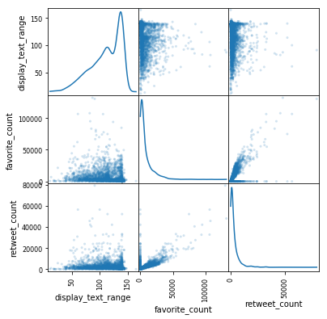

```python
# code
# Scatter Matrix Plot
from pandas.plotting import scatter_matrix
scatter_matrix(df, alpha=0.2, figsize=(6, 6), diagonal='kde');
```

```python
df.columns
x = df.columns[0]
y = df.columns[1]
z = df.columns[2]
x, y, z
```

```
('display_text_range', 'favorite_count', 'retweet_count')
```

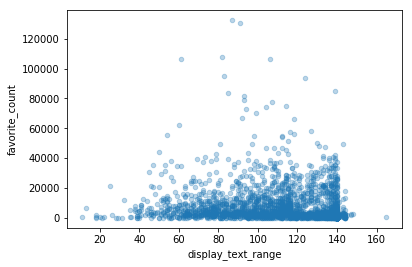

```python
df.plot.scatter(x,y,alpha=0.3);
```

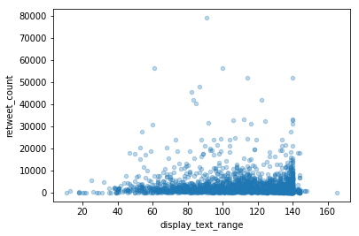

```python
df.plot.scatter(x,z,alpha=0.3);
```

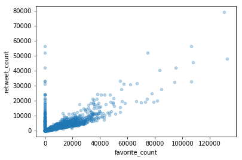

```python
df.plot.scatter(y,z,alpha=0.3);
```

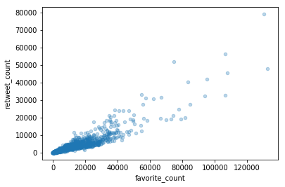

```python
df.query('favorite_count > 0').plot.scatter(y,z,alpha=0.3);
```

## / word cloud

### // word cloud library

```python
# code
#pip install wordcloud
```

### // word cloud official example

[figure not shown]

```python
from os import path
from PIL import Image
import numpy as np
import matplotlib.pyplot as plt
import os

from wordcloud import WordCloud, STOPWORDS, ImageColorGenerator

# get data directory (using getcwd() is needed to support running example in generated IPython notebook)
d = path.dirname(__file__) if "__file__" in locals() else os.getcwd()

# Read the whole text.
text = open(path.join(d, 'alice.txt')).read()

# read the mask / color image taken from
# http://jirkavinse.deviantart.com/art/quot-Real-Life-quot-Alice-282261010
alice_coloring = np.array(Image.open(path.join(d, "alice_color.png")))
stopwords = set(STOPWORDS)
stopwords.add("said")

wc = WordCloud(background_color="white", max_words=2000, mask=alice_coloring,
               stopwords=stopwords, max_font_size=40, random_state=42)
# generate word cloud
wc.generate(text)

# create coloring from image
image_colors = ImageColorGenerator(alice_coloring)

# show
fig, axes = plt.subplots(1, 3)
axes[0].imshow(wc, interpolation="bilinear")
# recolor wordcloud and show
# we could also give color_func=image_colors directly in the constructor
axes[1].imshow(wc.recolor(color_func=image_colors), interpolation="bilinear")
axes[2].imshow(alice_coloring, cmap=plt.cm.gray, interpolation="bilinear")
for ax in axes:
    ax.set_axis_off()
plt.show()
```

### // prepare word

```python
df.clean_text[:5]
```

```
time_index
2017-08-01 16:23:56    this is phineas. he's a mystical boy. only eve...
2017-08-01 00:17:27    this is tilly. she's just checking pup on you....
2017-07-31 00:18:03    this is archie. he is a rare norwegian pouncin...
2017-07-30 15:58:51     this is darla. she commenced a snooze mid meal.
2017-07-29 16:00:24    this is franklin. he would like you to stop ca...
Name: clean_text, dtype: object
```

```python
# 使用 sum 前要删除 null 值, 否则会报错
str_input = df.clean_text.dropna()
str_input.isnull().sum()
# 聚合方式可以参考
# https://stackoverflow.com/questions/47465542/how-to-concatenate-all-string-values-in-a-given-pandas-dataframe-row-to-one-st
```

```
0
```

```python
text_twitter = str_input.sum()
text_twitter[:1000]
```

```
'this is phineas. he\'s a mystical boy. only ever appears in the hole of a donut. this is tilly. she\'s just checking pup on you. hopes you\'re doing ok. if not, she\'s available for pats, snugs, boops, the whole bit. this is archie. he is a rare norwegian pouncing corgo. lives in the tall grass. yo…
```

### // word cloud

```python
# 将图像转为 np 二维数据 (所以是png还是jpeg应该没有关系)
# read the mask / color image taken from
color1 = np.array(Image.open("tweet1.jpeg"))
color2 = np.array(Image.open("tweet2.jpeg"))
color3 = np.array(Image.open("t1.png"))
color4 = np.array(Image.open("t2.png"))

# 设置停用词
stopwords = set(STOPWORDS)
stopwords.add("said")
```

```python
# wordcloud 参数
wc = WordCloud(background_color="white", max_words=2000,
               stopwords=stopwords, max_font_size=40, random_state=42)

## https://github.com/amueller/word_cloud
## git 中提供例子和cli(可以根据 text 和 pic 直接输出词云, 非常方便
```

```python
# wc.generate(text);
```

```python
wc.generate(text_twitter);
```

[figure not shown]

```python
# create coloring from image
image_colors = ImageColorGenerator(color4)

# 可以直接在构造函数中直接给颜色
# 通过这种方式词云将会按照给定的图片颜色布局生成字体颜色策略

# show
fig, axes = plt.subplots(1, 3, figsize=(24,4))
axes[0].imshow(wc, interpolation="bilinear")
# recolor wordcloud and show
# we could also give color_func=image_colors directly in the constructor
axes[1].imshow(wc.recolor(color_func=image_colors), interpolation="bilinear")
axes[2].imshow(color4, cmap=plt.cm.gray, interpolation="bilinear")
for ax in axes:
    ax.set_axis_off();
plt.show();
```

```python
# 增加 mask 蒙版系列
wc = WordCloud(background_color="white", max_words=2000, mask=color4,
               stopwords=stopwords, max_font_size=40, random_state=42)
wc.generate(text_twitter);
```

[figure not shown]

```python
# create coloring from image
image_colors = ImageColorGenerator(color4)

# 可以直接在构造函数中直接给颜色
# 通过这种方式词云将会按照给定的图片颜色布局生成字体颜色策略

# show
fig, axes = plt.subplots(1, 3, figsize=(24,4))
axes[0].imshow(wc, interpolation="bilinear")
# recolor wordcloud and show
# we could also give color_func=image_colors directly in the constructor
axes[1].imshow(wc.recolor(color_func=image_colors), interpolation="bilinear")
axes[2].imshow(color4, cmap=plt.cm.gray, interpolation="bilinear")
for ax in axes:
    ax.set_axis_off();
plt.show();
```

[figure not shown]

```python
# 输出两个图像做对比
# show
fig, axes = plt.subplots(2, 1, figsize=(20,4))
axes[0].imshow(wc.recolor(color_func=image_colors), interpolation="bilinear")
axes[1].imshow(color4, cmap=plt.cm.gray, interpolation="bilinear")
for ax in axes:
    ax.set_axis_off();
plt.show();
## 不是特别美观, 看来wordcloud如果使用mask和图像的样子关系很大
```

[figure not shown]

```python
# 增加 mask 蒙版系列2
wc = WordCloud(background_color="white", max_words=200, mask=color2,
               stopwords=stopwords, max_font_size=40, random_state=42)
wc.generate(text_twitter);

# create coloring from image
image_colors = ImageColorGenerator(color2)

# 可以直接在构造函数中直接给颜色
# 通过这种方式词云将会按照给定的图片颜色布局生成字体颜色策略

# 输出两个图像做对比
# show
fig, axes = plt.subplots(2, 1)
axes[0].imshow(wc.recolor(color_func=image_colors), interpolation="bilinear")
axes[1].imshow(color2, cmap=plt.cm.gray, interpolation="bilinear")
for ax in axes:
    ax.set_axis_off();
plt.show();
## 不是特别美观, 看来wordcloud如果使用mask和图像的样子关系很大
### 大小和图片分辨率相同
### 遇到有的图片会报错
## 感觉对分词如果用 nltk 处理下可能会更好
### https://sqlshep.com/?p=971
# 更新! relative_scaling 参数特别重要(见结论图)
```

## / time series analysis

https://ourcodingclub.github.io/2019/01/07/pandas-time-series.html

```python
df.head(10)
```

| time_index | display_text_range | favorite_count | retweet_count | clean_text |
| --- | --- | --- | --- | --- |
| 2017-08-01 16:23:56 | 85 | 39492 | 8842 | this is phineas. he's a mystical boy. only eve... |
| 2017-08-01 00:17:27 | 138 | 33786 | 6480 | this is tilly. she's just checking pup on you.... |
| 2017-07-31 00:18:03 | 121 | 25445 | 4301 | this is archie. he is a rare norwegian pouncin... |
| 2017-07-30 15:58:51 | 79 | 42863 | 8925 | this is darla. she commenced a snooze mid meal. |
| 2017-07-29 16:00:24 | 138 | 41016 | 9721 | this is franklin. he would like you to stop ca... |
| 2017-07-29 00:08:17 | 138 | 20548 | 3240 | here we have a majestic great white breaching ... |
| 2017-07-28 16:27:12 | 140 | 12053 | 2142 | meet jax. he enjoys ice cream so much he gets ... |
| 2017-07-28 00:22:40 | 118 | 66596 | 19548 | when you watch your owner call another dog a g... |
| 2017-07-27 16:25:51 | 122 | 28187 | 4403 | this is zoey. she doesn't want to be one of th... |
| 2017-07-26 15:59:51 | 133 | 32467 | 7684 | this is cassie. she is a college pup. studying... |

```python
# check intervals
print("Dataframe shape: ", df.shape)
dt = (df.index[0] - df.index[-1])
print("Number of hours between start and end dates: ", dt.total_seconds()/3600 + 1)
dt
```

```
Dataframe shape:  (2352, 4)
Number of hours between start and end dates:  14994.863333333333
```

```
Timedelta('624 days 17:51:48')
```

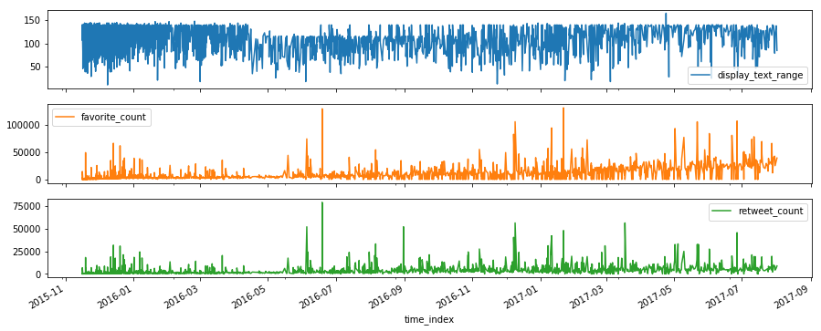

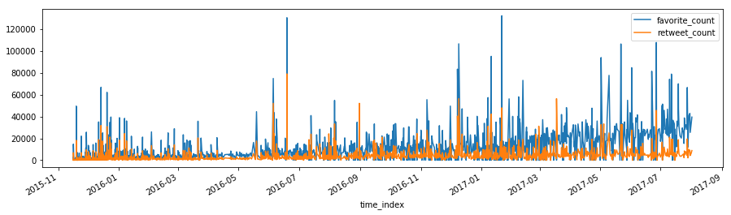

```python
#df.plot(figsize=(15,4))
df.plot(subplots=True, figsize=(15,6))
df.plot(y=["favorite_count", "retweet_count"], figsize=(15,4));
```

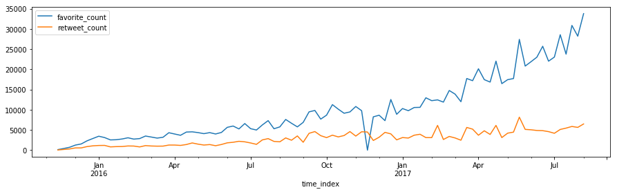

```python
df[["favorite_count", "retweet_count"]].resample("1w").median().plot(figsize=(15,4));
```

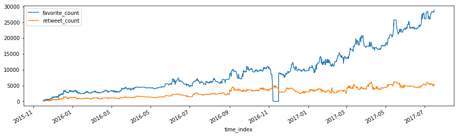

```python
df[["favorite_count", "retweet_count"]].rolling(30).median().plot(figsize=(15,4));
```

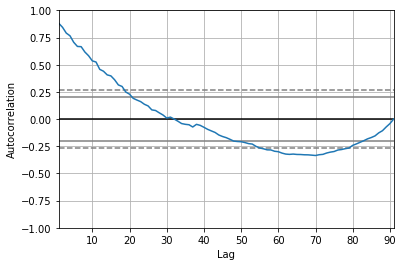

```python
# 如果是周期的可以用这个(后续研究)
pd.plotting.autocorrelation_plot(df["favorite_count"].resample("1w").median());
```

## / sentiment analysis

- 使用sklearn https://towardsdatascience.com/sentiment-analysis-with-python-part-1-5ce197074184
- 另外比较常见的是使用 nltk 库
- 此处先pass, 深度学习时候有空再深入